# Lab 4: Sequential Data

This lab is based on an assignment developed by Prof. Lisa Zhang.

In this assignment, we will build a recurrent neural network to classify a SMS text message as "spam" or "not spam". In the process, you will

1. Clean and process text data for machine learning.
2. Understand and implement a character-level recurrent neural network.
3. Use torchtext to build recurrent neural network models.
4. Understand batching for a recurrent neural network, and use torchtext to implement RNN batching.
5. Understand how transfer learning can be applied to NLP projects.

### What to submit

Submit an HTML file containing all your code, outputs, and write-up from parts A and B. You can produce a HTML file directly from Google Colab. The Colab instructions are provided at the end of this document.

**Do not submit any other files produced by your code.**

Include a link to your colab file in your submission.

Please use Google Colab to complete this assignment. If you want to use Jupyter Notebook, please complete the assignment and upload your Jupyter Notebook file to Google Colab for submission.

## Colab Link

Include a link to your colab file here

Colab Link: https://colab.research.google.com/drive/1KYNCu5VjSii30nOknoMrGtJ5HhpO6aAI?usp=sharing

# PART A - Spam Detection [30 pt]

In this part we will construct a LSTM model for identifying spam from non spam messages.

```python
import torch
import torch.nn as nn
import torch.nn.functional as F
import torch.optim as optim
import numpy as np
```

## Part 1. Data Cleaning [10 pt]

We will be using the "SMS Spam Collection Data Set" available at http://archive.ics.uci.edu/ml/datasets/SMS+Spam+Collection

There is a link to download the "Data Folder" at the very top of the webpage. Download the zip file, unzip it, and upload the file `SMSSpamCollection` to Colab.

### Part (a) [1 pt]

Open up the file in Python, and print out one example of a spam SMS, and one example of a non-spam SMS.

What is the label value for a spam message, and what is the label value for a non-spam message?

```python
#setup Google Drive
from google.colab import drive
drive.mount('/content/drive')
```

```python
# file location (make sure to use your file location)
file_dir = '/content/drive/My Drive/Colab Notebooks/Lab 4/SMSSpamCollection'

for line in open(file_dir):
  print(line)
  break
```

```
ham	Go until jurong point, crazy.. Available only in bugis n great world la e buffet... Cine there got amore wat...
```

The label for a spam message is 'spam' and the label for a non-spam message is 'ham'

### Part (b) [1 pt]

How many spam messages are there in the data set? How many non-spam messages are there in the data set?

```python
num_spam = []
num_ham = []
for line in open(file_dir):
  label = line[0:4]
  if label=='spam':
    num_spam.append(1)
  else:
    num_ham.append(1)

print('Number of spam messages in dataset: ', len(num_spam))
print('Number of non-spam messages in dataset: ', len(num_ham))
```

```
Number of spam messages in dataset:  747
Number of non-spam messages in dataset:  4827
```

### Part (c) [2 pt]

We will be using the package `torchtext` to load, process, and batch the data. A tutorial to torchtext is available below. This tutorial uses the same Sentiment140 data set that we explored during lecture.

https://medium.com/@sonicboom8/sentiment-analysis-torchtext-55fb57b1fab8

Unlike what we did during lecture, we will be building a **character level RNN**. That is, we will treat each **character** as a token in our sequence, rather than each **word**.

Identify two advantage and two disadvantage of modelling SMS text messages as a sequence of characters rather than a sequence of words.

**Advantages of character-level Modeling**

- Can be used to model languages other than English better
- Discrete space is smaller than when using word-level

**Disadvantages of character-level Modeling**

- Computationally expensive compared to word-level modeling
- Require more complex architectures (larger hidden layers)

### Part (d) [1 pt]

We will be loading our data set using `torchtext.data.TabularDataset`. The constructor will read directly from the `SMSSpamCollection` file.

For the data file to be read successfuly, we need to specify the **fields** (columns) in the file. In our case, the dataset has two fields:

- a text field containing the sms messages,
- a label field which will be converted into a binary label.

Split the dataset into `train`, `valid`, and `test`. Use a 60-20-20 split. You may find this torchtext API page helpful: https://torchtext.readthedocs.io/en/latest/data.html#dataset

Hint: There is a `Dataset` method that can perform the random split for you.

```python
import torchtext
# from torchtext.legacy.data import split

text_field = torchtext.legacy.data.Field(sequential=True,      # text sequence
                                  tokenize=lambda x: x, # because are building a character-RNN
                                  include_lengths=True, # to track the length of sequences, for batching
                                  batch_first=True,
                                  use_vocab=True)       # to turn each character into an integer index
label_field = torchtext.legacy.data.Field(sequential=False,    # not a sequence
                                   use_vocab=False,     # don't need to track vocabulary
                                   is_target=True,
                                   batch_first=True,
                                   preprocessing=lambda x: int(x == 'spam')) # convert text to 0 and 1

fields = [('label', label_field), ('sms', text_field)]
dataset = torchtext.legacy.data.TabularDataset(file_dir, # name of the file
                                        "tsv",               # fields are separated by a tab
                                        fields)

sr = [0.6, 0.2, 0.2]




print(dataset[0].sms)
print(dataset[0].label)
train, valid, test = dataset.split(sr)
```

```
Go until jurong point, crazy.. Available only in bugis n great world la e buffet... Cine there got amore wat...
0
```

### Part (e) [2 pt]

You saw in part (b) that there are many more non-spam messages than spam messages. This **imbalance** in our training data will be problematic for training. We can fix this disparity by duplicating spam messages in the training set, so that the training set is roughly **balanced**.

Explain why having a balanced training set is helpful for training our neural network.

Note: if you are not sure, try removing the below code and train your mode.

A balanced training set is helpful for training a neural network because it addressed the issue of overfitting on one type of label over the other. We want a balanced dataset to allow the NN to fully learn the relationships between the data and BOTH labels

```python
# save the original training examples
old_train_examples = train.examples
# get all the spam messages in `train`
train_spam = []
for item in train.examples:
    if item.label == 1:
        train_spam.append(item)
# duplicate each spam message 6 more times
train.examples = old_train_examples + train_spam * 6
```

### Part (f) [1 pt]

We need to build the vocabulary on the training data by running the below code. This finds all the possible character tokens in the training set.

Explain what the variables `text_field.vocab.stoi` and `text_field.vocab.itos` represent.

The text_field.vocab.stoi variable is the dictionary for the characters to numbers, while the text_field.vocab.itos is all the possible characters

```python
text_field.build_vocab(train)
print(text_field.vocab.stoi)
# print(text_field.vocab.itos)
```

```
defaultdict(<bound method Vocab._default_unk_index of <torchtext.legacy.vocab.Vocab object at 0x7f9e47846a10>>, {'<unk>': 0, '<pad>': 1, ' ': 2, 'e': 3, 'o': 4, 't': 5, 'a': 6, 'n': 7, 'r': 8, 'i': 9, 's': 10, 'l': 11, 'u': 12, 'h': 13, '0': 14, 'd': 15, '.': 16, 'c': 17, 'm': 18, 'y': 19, 'w': 20, …
```

### Part (g) [1 pt]

The tokens `<unk>` and `<pad>` were not in our SMS text messages. What do these two values represent?

### Part (h) [1 pt]

Since text sequences are of variable length, `torchtext` provides a `BucketIterator` data loader, which batches similar length sequences together. The iterator also provides functionalities to pad sequences automatically.

Take a look at 10 batches in `train_iter`. What is the maximum length of the input sequence in each batch? How many `<pad>` tokens are used in each of the 10 batches?

```python
train_iter = torchtext.legacy.data.BucketIterator(train,
                                           batch_size=32,
                                           sort_key=lambda x: len(x.sms), # to minimize padding
                                           sort_within_batch=True,        # sort within each batch
                                           repeat=False)                  # repeat the iterator for many epochs
```

```python
import tensorflow as tf
import numpy as np
i = 0
for batch in train_iter:
    i += 1
    print('Batch number ', i)
    batch_sms = (batch.sms[0]).numpy()
    emb_batch = F.one_hot(batch.sms[0],115)
    print(emb_batch.shape)
    ones = []
    for j in range(len(batch_sms)):
      sms = batch_sms[j]
      for z in range(len(sms)):
        token = sms[z]
        if token==1:
          ones.append(1)

    print('Number of pad tokens in batch: ', len(ones))
    print('Maximum length of input sequence in batch: ', batch.sms[0].shape[1])
    # print('Embedding dim' , batch.sms[1].shape[0])
    if i==10:
      break
```

```
Batch number  1
torch.Size([32, 143, 115])
Number of pad tokens in batch:  15
Maximum length of input sequence in batch:  143
Batch number  2
torch.Size([32, 147, 115])
Number of pad tokens in batch:  22
Maximum length of input sequence in batch:  147
Batch number  3
torch.Size([32, 33, 115])
Number of pad tokens in batch:  20
Maximum length of input sequence in batch:  33
Batch number  4
torch.Size([32, 34, 115])
Number of pad tokens in batch:  16
Maximum length of input sequence in batch:  34
Batch number  5
torch.Size([32, 27, 115])
Number of pad tokens in batch:  11
Maximum length of input sequence in batch:  27
Batch number  6
torch.Size([32, 51, 115])
Number of pad tokens in batch:  29
Maximum length of input sequence in batch:  51
Batch number  7
torch.Size([32, 157, 115])
Number of pad tokens in batch:  0
Maximum length of input sequence in batch:  157
Batch number  8
torch.Size([32, 144, 115])
Number of pad tokens in batch:  21
Maximum length of input sequence in batch:  144
Batch number  9
torch.Size([32, 141, 115])
Number of pad tokens in batch:  26
Maximum length of input sequence in batch:  141
Batch number  10
torch.Size([32, 145, 115])
Number of pad tokens in batch:  18
Maximum length of input sequence in batch:  145
```

## Part 2. Model Building [5 pt]

Build a recurrent neural network model, using an architecture of your choosing. Use the one-hot embedding of each character as input to your recurrent network. Use one or more fully-connected layers to make the prediction based on your recurrent network output.

Instead of using the RNN output value for the final token, another often used strategy is to max-pool over the entire output array. That is, instead of calling something like:

```
out, _ = self.rnn(x)
self.fc(out[:, -1, :])
```

where `self.rnn` is an `nn.RNN`, `nn.GRU`, or `nn.LSTM` module, and `self.fc` is a fully-connected layer, we use:

```
out, _ = self.rnn(x)
self.fc(torch.max(out, dim=1)[0])
```

This works reasonably in practice. An even better alternative is to concatenate the max-pooling and average-pooling of the RNN outputs:

```
out, _ = self.rnn(x)
out = torch.cat([torch.max(out, dim=1)[0],
                 torch.mean(out, dim=1)], dim=1)
self.fc(out)
```

We encourage you to try out all these options. The way you pool the RNN outputs is one of the "hyperparameters" that you can choose to tune later on.

```python
# You might find this code helpful for obtaining
# PyTorch one-hot vectors.

ident = torch.eye(10)
print(ident[0]) # one-hot vector
print(ident[1]) # one-hot vector
x = torch.tensor([[1, 2], [3, 4]])
print(ident[x]) # one-hot vectors
```

```
tensor([1., 0., 0., 0., 0., 0., 0., 0., 0., 0.])
tensor([0., 1., 0., 0., 0., 0., 0., 0., 0., 0.])
tensor([[[0., 1., 0., 0., 0., 0., 0., 0., 0., 0.],
         [0., 0., 1., 0., 0., 0., 0., 0., 0., 0.]],

        [[0., 0., 0., 1., 0., 0., 0., 0., 0., 0.],
         [0., 0., 0., 0., 1., 0., 0., 0., 0., 0.]]])
```

```python
import torch.nn.functional as F
```

```python
class SMSSpamLSTM(nn.Module):
  def __init__(self, input_size,hidden_size, num_classes):
    super(SMSSpamLSTM, self).__init__()
    self.hidden_size = hidden_size
    self.lstm = nn.LSTM(input_size, hidden_size, batch_first=True)
    self.fc = nn.Linear(hidden_size, num_classes)

  def forward(self, x):
    ident = torch.eye(115)
    x=ident[x] # one-hot vectors
    # x = F.one_hot(x.to(torch.int64), 115)
    # x=x.type(torch.float)
    # print(x.shape)
    h0 = torch.zeros(1, x.size(0), self.hidden_size)
    h0 = h0
    c0 = torch.zeros(1, x.size(0), self.hidden_size)
    c0 = c0
    # print('ARCHITECTURE TYPES: ', x.dtype, h0.dtype, c0.dtype)
    out, _ = self.lstm(x, (h0, c0))
    out = self.fc(out[:, -1, :])
    return out
```

## Part 3. Training [8 pt]

### Part (a) [2 pt]

Complete the `get_accuracy` function, which will compute the accuracy (rate) of your model across a dataset (e.g. validation set). You may modify `torchtext.data.BucketIterator` to make your computation faster.

```python
def get_accuracy(model, data, batch_size):
    """ Compute the accuracy of the `model` across a dataset `data`

    Example usage:

    >>> model = MyRNN() # to be defined
    >>> get_accuracy(model, valid) # the variable `valid` is from above
    """
    correct, total = 0, 0
    data_iter = torchtext.legacy.data.BucketIterator(data, batch_size=batch_size, sort_key=lambda x: len(x.sms), sort_within_batch=True,repeat=False)
    for batch in data_iter:
      sms = (batch.sms[0])
      labels = (batch.label)
      input_size = 115
      out = model(sms)
      # print(out)
      pred = out.max(1, keepdim=True)[1]
      correct += pred.eq(labels.view_as(pred)).sum().item()
      total += labels.shape[0]
    return correct/total
```

### Part (b) [2 pt]

Train your model. Plot the training curve of your final model. Your training curve should have the training/validation loss and accuracy plotted periodically.

Note: Not all of your batches will have the same batch size. In particular, if your training set does not divide evenly by your batch size, there will be a batch that is smaller than the rest.

```python
import matplotlib.pyplot as plt

def train_rnn_network(model, train, valid, num_epochs=5, batch_size = 32, learning_rate=1e-5):
    criterion = nn.CrossEntropyLoss()
    optimizer = torch.optim.Adam(model.parameters(), lr=learning_rate)
    losses, train_acc, valid_acc = [], [], []
    train_iter = torchtext.legacy.data.BucketIterator(train, batch_size=batch_size, sort_key=lambda x: len(x.sms), sort_within_batch=True,repeat=False)
    epochs = []
    for epoch in range(num_epochs):
        for batch in train_iter:
            optimizer.zero_grad()
            sms = (batch.sms[0])
            labels = (batch.label)
            # print('Training sms, label types: ', sms.dtype, labels.dtype)
            pred = model(sms)
            # print(pred)
            loss = criterion(pred, labels)
            loss.backward()
            optimizer.step()
        losses.append(float(loss))

        epochs.append(epoch)
        train_acc.append(get_accuracy(model, train, batch_size))
        valid_acc.append(get_accuracy(model, valid, batch_size))
        print("Epoch %d; Loss %f; Train Acc %f; Val Acc %f" % (
              epoch+1, loss, train_acc[-1], valid_acc[-1]))
    # plotting
    plt.title("Training Curve")
    plt.plot(losses, label="Train")
    plt.xlabel("Epoch")
    plt.ylabel("Loss")
    plt.show()

    plt.title("Training Curve")
    plt.plot(epochs, train_acc, label="Train")
    plt.plot(epochs, valid_acc, label="Validation")
    plt.xlabel("Epoch")
    plt.ylabel("Accuracy")
    plt.legend(loc='best')
    plt.show()
```

```
Epoch 1; Loss 0.660058; Train Acc 0.627640; Val Acc 0.863677
Epoch 2; Loss 0.371531; Train Acc 0.932313; Val Acc 0.949776
Epoch 3; Loss 0.447153; Train Acc 0.934309; Val Acc 0.927354
Epoch 4; Loss 0.266092; Train Acc 0.880925; Val Acc 0.958744
Epoch 5; Loss 0.389202; Train Acc 0.928488; Val Acc 0.961435
Epoch 6; Loss 0.107654; Train Acc 0.941793; Val Acc 0.956054
Epoch 7; Loss 0.047527; Train Acc 0.945285; Val Acc 0.951570
Epoch 8; Loss 0.354881; Train Acc 0.750707; Val Acc 0.630493
Epoch 9; Loss 0.193017; Train Acc 0.947946; Val Acc 0.944395
Epoch 10; Loss 0.221340; Train Acc 0.894728; Val Acc 0.831390
Epoch 11; Loss 0.055764; Train Acc 0.952270; Val Acc 0.949776
Epoch 12; Loss 0.127488; Train Acc 0.954931; Val Acc 0.953363
Epoch 13; Loss 0.061208; Train Acc 0.957093; Val Acc 0.959641
Epoch 14; Loss 0.403882; Train Acc 0.943456; Val Acc 0.930942
Epoch 15; Loss 0.218382; Train Acc 0.953933; Val Acc 0.953363
Epoch 16; Loss 0.037967; Train Acc 0.952270; Val Acc 0.947982
Epoch 17; Loss 0.171726; Train Acc 0.960585; Val Acc 0.961435
Epoch 18; Loss 0.243709; Train Acc 0.960419; Val Acc 0.965022
Epoch 19; Loss 0.031244; Train Acc 0.947780; Val Acc 0.967713
Epoch 20; Loss 0.159145; Train Acc 0.897223; Val Acc 0.841256
```

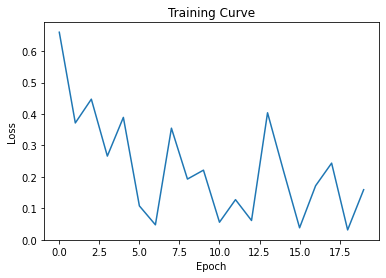

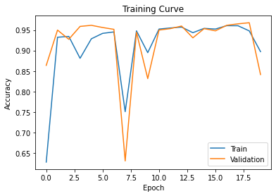

```
Testing accuracy:
```

```
0.8357271095152603
```

```python
hidden_size = 50
num_classes = 2
model = SMSSpamLSTM(115, hidden_size, num_classes)

train_rnn_network(model, train, valid, num_epochs=20, batch_size=32, learning_rate=2e-4)
print('Testing accuracy: ')
get_accuracy(model, test, batch_size=32)
```

### Part (c) [2 pt]

Choose at least 4 hyperparameters to tune. Explain how you tuned the hyperparameters. You don't need to include your training curve for every model you trained. Instead, explain what hyperparemters you tuned, what the best validation accuracy was, and the reasoning behind the hyperparameter decisions you made.

For this assignment, you should tune more than just your learning rate and epoch. Choose at least 2 hyperparameters that are unrelated to the optimizer.

```
Epoch 1; Loss 0.698319; Train Acc 0.561118; Val Acc 0.203587
Epoch 2; Loss 0.492350; Train Acc 0.920838; Val Acc 0.968610
Epoch 3; Loss 0.419833; Train Acc 0.924331; Val Acc 0.968610
Epoch 4; Loss 0.351788; Train Acc 0.945452; Val Acc 0.959641
Epoch 5; Loss 0.343942; Train Acc 0.939797; Val Acc 0.973991
Epoch 6; Loss 0.228525; Train Acc 0.945784; Val Acc 0.965022
Epoch 7; Loss 0.026597; Train Acc 0.939797; Val Acc 0.930942
Epoch 8; Loss 0.025154; Train Acc 0.944620; Val Acc 0.973094
Epoch 9; Loss 0.337173; Train Acc 0.949775; Val Acc 0.966816
Epoch 10; Loss 0.283745; Train Acc 0.525861; Val Acc 0.146188
Epoch 11; Loss 0.324014; Train Acc 0.734575; Val Acc 0.691480
Epoch 12; Loss 0.334404; Train Acc 0.750374; Val Acc 0.835874
Epoch 13; Loss 0.029981; Train Acc 0.940961; Val Acc 0.925561
Epoch 14; Loss 0.169788; Train Acc 0.948445; Val Acc 0.957848
Epoch 15; Loss 0.375647; Train Acc 0.925827; Val Acc 0.971300
Epoch 16; Loss 0.132933; Train Acc 0.949775; Val Acc 0.943498
Epoch 17; Loss 0.217413; Train Acc 0.954765; Val Acc 0.957848
Epoch 18; Loss 0.160248; Train Acc 0.960086; Val Acc 0.948879
Epoch 19; Loss 0.050960; Train Acc 0.949277; Val Acc 0.970404
Epoch 20; Loss 0.369567; Train Acc 0.915683; Val Acc 0.976682
```

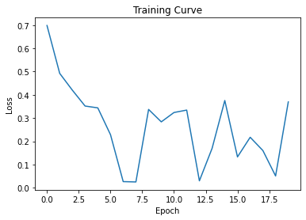

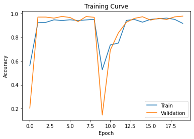

```
Testing accuracy:
```

```
0.9775583482944344
```

```python
## Hyperparameter of choice: Pooling Option

class SMSSpamLSTM2(nn.Module):
  def __init__(self, input_size,hidden_size, num_classes):
    super(SMSSpamLSTM2, self).__init__()
    self.hidden_size = hidden_size
    self.lstm = nn.LSTM(input_size, hidden_size, batch_first=True)
    self.fc = nn.Linear(hidden_size, num_classes)

  def forward(self, x):
    ident = torch.eye(115)
    x=ident[x]
    h0 = torch.zeros(1, x.size(0), self.hidden_size)
    h0 = h0
    c0 = torch.zeros(1, x.size(0), self.hidden_size)
    c0 = c0
    # print('ARCHITECTURE TYPES: ', x.dtype, h0.dtype, c0.dtype)
    out, _ = self.lstm(x, (h0, c0))
    out = self.fc(torch.max(out, dim=1)[0])
    return out

hidden_size = 50
num_classes = 2
model = SMSSpamLSTM2(115, hidden_size, num_classes)

train_rnn_network(model, train, valid, num_epochs=20, batch_size=32, learning_rate=2e-4)
print('Testing accuracy: ')
get_accuracy(model, test, batch_size=32)
```

```
Epoch 1; Loss 0.717315; Train Acc 0.529686; Val Acc 0.162332
Epoch 2; Loss 0.382052; Train Acc 0.922834; Val Acc 0.962332
Epoch 3; Loss 0.313401; Train Acc 0.925661; Val Acc 0.976682
Epoch 4; Loss 0.193668; Train Acc 0.945784; Val Acc 0.967713
Epoch 5; Loss 0.342579; Train Acc 0.921503; Val Acc 0.977578
Epoch 6; Loss 0.076873; Train Acc 0.907201; Val Acc 0.973991
Epoch 7; Loss 0.016779; Train Acc 0.937469; Val Acc 0.975785
Epoch 8; Loss 0.022860; Train Acc 0.947281; Val Acc 0.970404
Epoch 9; Loss 0.475345; Train Acc 0.947614; Val Acc 0.970404
Epoch 10; Loss 0.108045; Train Acc 0.947447; Val Acc 0.970404
```

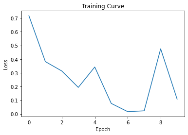

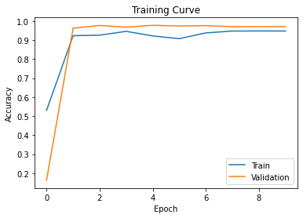

```
Testing accuracy:
```

```
0.9748653500897666
```

```python
## Hyperparameter of choice: Hidden layer size

hidden_size = 100
num_classes = 2
model = SMSSpamLSTM2(115, hidden_size, num_classes)

train_rnn_network(model, train, valid, num_epochs=10, batch_size=32, learning_rate=2e-4)
print('Testing accuracy: ')
get_accuracy(model, test, batch_size=32)
```

```
Epoch 1; Loss 0.640593; Train Acc 0.518044; Val Acc 0.145291
Epoch 2; Loss 0.770776; Train Acc 0.518044; Val Acc 0.145291
Epoch 3; Loss 0.167887; Train Acc 0.932480; Val Acc 0.956054
Epoch 4; Loss 0.547758; Train Acc 0.939132; Val Acc 0.958744
Epoch 5; Loss 0.196748; Train Acc 0.927657; Val Acc 0.973991
Epoch 6; Loss 0.138825; Train Acc 0.906536; Val Acc 0.973094
Epoch 7; Loss 0.316577; Train Acc 0.914851; Val Acc 0.975785
Epoch 8; Loss 0.297059; Train Acc 0.924164; Val Acc 0.976682
Epoch 9; Loss 0.050932; Train Acc 0.945285; Val Acc 0.942601
Epoch 10; Loss 0.160476; Train Acc 0.937136; Val Acc 0.972197
```

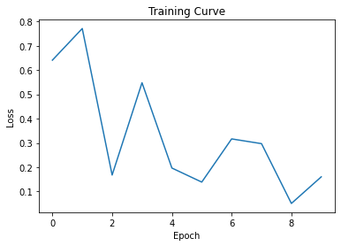

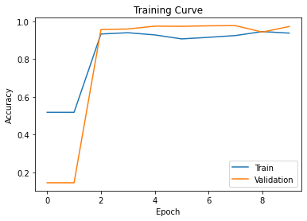

```
Testing accuracy:
```

```
0.9766606822262118
```

```python
## Hyperparameter of choice: Batch Size

hidden_size = 100
num_classes = 2
model = SMSSpamLSTM2(115, hidden_size, num_classes)

train_rnn_network(model, train, valid, num_epochs=10, batch_size=64, learning_rate=2e-4)
print('Testing accuracy: ')
get_accuracy(model, test, batch_size=64)
```

```
Epoch 1; Loss 0.652737; Train Acc 0.518044; Val Acc 0.145291
Epoch 2; Loss 0.736552; Train Acc 0.518044; Val Acc 0.145291
Epoch 3; Loss 0.656800; Train Acc 0.518044; Val Acc 0.145291
Epoch 4; Loss 0.734987; Train Acc 0.518044; Val Acc 0.145291
Epoch 5; Loss 0.648901; Train Acc 0.518044; Val Acc 0.145291
Epoch 6; Loss 0.653499; Train Acc 0.518044; Val Acc 0.145291
Epoch 7; Loss 0.736123; Train Acc 0.518044; Val Acc 0.145291
Epoch 8; Loss 0.654554; Train Acc 0.518044; Val Acc 0.145291
Epoch 9; Loss 0.656111; Train Acc 0.518044; Val Acc 0.145291
Epoch 10; Loss 0.724861; Train Acc 0.518044; Val Acc 0.145291
```

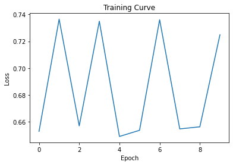

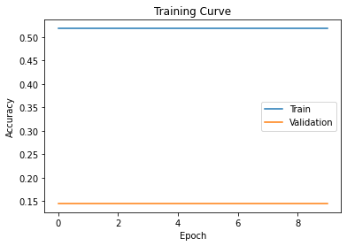

```
Testing accuracy:
```

```
0.12567324955116696
```

```python
## Hyperparameter of choice: Learning Rate

hidden_size = 100
num_classes = 2
model = SMSSpamLSTM2(115, hidden_size, num_classes)

train_rnn_network(model, train, valid, num_epochs=10, batch_size=64, learning_rate=1e-5)
print('Testing accuracy: ')
get_accuracy(model, test, batch_size=64)
```

```
Epoch 1; Loss 0.303031; Train Acc 0.927490; Val Acc 0.975785
Epoch 2; Loss 0.279624; Train Acc 0.943456; Val Acc 0.961435
Epoch 3; Loss 0.030811; Train Acc 0.941793; Val Acc 0.972197
Epoch 4; Loss 0.095809; Train Acc 0.943456; Val Acc 0.971300
Epoch 5; Loss 0.028564; Train Acc 0.919175; Val Acc 0.895067
Epoch 6; Loss 0.021777; Train Acc 0.957592; Val Acc 0.973991
Epoch 7; Loss 0.103722; Train Acc 0.962415; Val Acc 0.973094
Epoch 8; Loss 0.193604; Train Acc 0.962914; Val Acc 0.976682
Epoch 9; Loss 0.013587; Train Acc 0.967071; Val Acc 0.967713
Epoch 10; Loss 0.056604; Train Acc 0.968568; Val Acc 0.967713
```

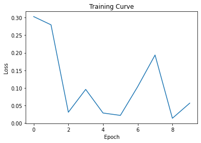

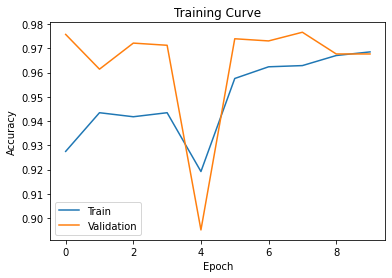

```
Testing accuracy:
```

```
0.9757630161579892
```

```python
## Hyperparameter of choice: Learning Rate

hidden_size = 100
num_classes = 2
model = SMSSpamLSTM2(115, hidden_size, num_classes)

train_rnn_network(model, train, valid, num_epochs=10, batch_size=64, learning_rate=1e-3)
print('Testing accuracy: ')
get_accuracy(model, test, batch_size=64)
```

```
Epoch 1; Loss 0.613958; Train Acc 0.518044; Val Acc 0.145291
Epoch 2; Loss 0.794816; Train Acc 0.518044; Val Acc 0.145291
Epoch 3; Loss 0.155351; Train Acc 0.942292; Val Acc 0.952466
Epoch 4; Loss 0.574559; Train Acc 0.931482; Val Acc 0.974888
Epoch 5; Loss 0.350461; Train Acc 0.834359; Val Acc 0.956951
Epoch 6; Loss 0.116536; Train Acc 0.928987; Val Acc 0.973991
Epoch 7; Loss 0.368329; Train Acc 0.920838; Val Acc 0.973991
Epoch 8; Loss 0.341655; Train Acc 0.922335; Val Acc 0.974888
Epoch 9; Loss 0.154307; Train Acc 0.903542; Val Acc 0.978475
Epoch 10; Loss 0.307681; Train Acc 0.929320; Val Acc 0.975785
Epoch 11; Loss 0.276388; Train Acc 0.933644; Val Acc 0.976682
Epoch 12; Loss 0.294918; Train Acc 0.947780; Val Acc 0.966816
Epoch 13; Loss 0.079517; Train Acc 0.934309; Val Acc 0.973094
Epoch 14; Loss 0.167206; Train Acc 0.939797; Val Acc 0.972197
Epoch 15; Loss 0.184719; Train Acc 0.939631; Val Acc 0.972197
Epoch 16; Loss 0.348474; Train Acc 0.947780; Val Acc 0.967713
Epoch 17; Loss 0.042917; Train Acc 0.948778; Val Acc 0.968610
Epoch 18; Loss 0.113962; Train Acc 0.939631; Val Acc 0.972197
Epoch 19; Loss 0.125209; Train Acc 0.950108; Val Acc 0.968610
Epoch 20; Loss 0.230402; Train Acc 0.951272; Val Acc 0.965022
Epoch 21; Loss 0.493647; Train Acc 0.622651; Val Acc 0.869058
Epoch 22; Loss 0.621365; Train Acc 0.697988; Val Acc 0.507623
Epoch 23; Loss 0.476128; Train Acc 0.731582; Val Acc 0.591928
Epoch 24; Loss 0.554451; Train Acc 0.808082; Val Acc 0.843946
Epoch 25; Loss 0.447273; Train Acc 0.824879; Val Acc 0.842152
Epoch 26; Loss 0.645481; Train Acc 0.816398; Val Acc 0.866368
Epoch 27; Loss 0.397618; Train Acc 0.834858; Val Acc 0.864574
Epoch 28; Loss 0.400486; Train Acc 0.854482; Val Acc 0.841256
Epoch 29; Loss 0.373366; Train Acc 0.876601; Val Acc 0.867265
Epoch 30; Loss 0.529052; Train Acc 0.898886; Val Acc 0.859193
Epoch 31; Loss 0.166745; Train Acc 0.874938; Val Acc 0.806278
Epoch 32; Loss 0.192869; Train Acc 0.933644; Val Acc 0.961435
Epoch 33; Loss 0.141338; Train Acc 0.947946; Val Acc 0.944395
Epoch 34; Loss 0.062525; Train Acc 0.946283; Val Acc 0.938117
Epoch 35; Loss 0.178047; Train Acc 0.953933; Val Acc 0.959641
Epoch 36; Loss 0.073922; Train Acc 0.954099; Val Acc 0.952466
Epoch 37; Loss 0.187353; Train Acc 0.954099; Val Acc 0.968610
Epoch 38; Loss 0.054189; Train Acc 0.954598; Val Acc 0.971300
Epoch 39; Loss 0.069973; Train Acc 0.955430; Val Acc 0.971300
Epoch 40; Loss 0.249765; Train Acc 0.868784; Val Acc 0.973094
```

[output cut: 45 more lines]

```
Epoch 86; Loss 0.012720; Train Acc 0.965575; Val Acc 0.973991
Epoch 87; Loss 0.028414; Train Acc 0.969732; Val Acc 0.974888
Epoch 88; Loss 0.350416; Train Acc 0.972061; Val Acc 0.970404
Epoch 89; Loss 0.017886; Train Acc 0.973890; Val Acc 0.973094
Epoch 90; Loss 0.009749; Train Acc 0.974888; Val Acc 0.974888
Epoch 91; Loss 0.042476; Train Acc 0.967903; Val Acc 0.977578
Epoch 92; Loss 0.032329; Train Acc 0.977549; Val Acc 0.979372
Epoch 93; Loss 0.203544; Train Acc 0.969899; Val Acc 0.977578
Epoch 94; Loss 0.006475; Train Acc 0.980376; Val Acc 0.975785
Epoch 95; Loss 0.333880; Train Acc 0.972227; Val Acc 0.981166
Epoch 96; Loss 0.008721; Train Acc 0.980542; Val Acc 0.979372
Epoch 97; Loss 0.059657; Train Acc 0.982538; Val Acc 0.975785
Epoch 98; Loss 0.045226; Train Acc 0.981207; Val Acc 0.978475
Epoch 99; Loss 0.046204; Train Acc 0.969566; Val Acc 0.954260
Epoch 100; Loss 0.251270; Train Acc 0.981540; Val Acc 0.979372
```

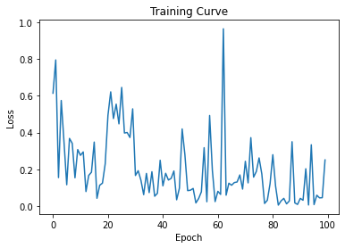

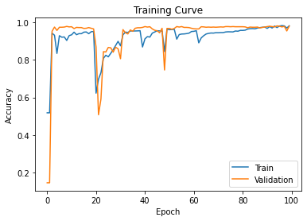

```
Testing accuracy:
```

```
0.9802513464991023
```

```python
## Hyperparameter of choice: Epochs

hidden_size = 100
num_classes = 2
model = SMSSpamLSTM2(115, hidden_size, num_classes)

train_rnn_network(model, train, valid, num_epochs=100, batch_size=64, learning_rate=2e-4)
print('Testing accuracy: ')
get_accuracy(model, test, batch_size=64)
```

```
Epoch 1; Loss 0.698006; Train Acc 0.492599; Val Acc 0.855605
Epoch 2; Loss 0.721611; Train Acc 0.525362; Val Acc 0.156054
Epoch 3; Loss 0.235892; Train Acc 0.939797; Val Acc 0.952466
Epoch 4; Loss 0.588714; Train Acc 0.934143; Val Acc 0.955157
Epoch 5; Loss 0.379661; Train Acc 0.926992; Val Acc 0.959641
Epoch 6; Loss 0.199117; Train Acc 0.941959; Val Acc 0.943498
Epoch 7; Loss 0.495207; Train Acc 0.936471; Val Acc 0.955157
Epoch 8; Loss 0.344276; Train Acc 0.935473; Val Acc 0.961435
Epoch 9; Loss 0.141821; Train Acc 0.936970; Val Acc 0.962332
Epoch 10; Loss 0.235248; Train Acc 0.909696; Val Acc 0.969507
Epoch 11; Loss 0.892256; Train Acc 0.566273; Val Acc 0.209865
Epoch 12; Loss 0.161436; Train Acc 0.944121; Val Acc 0.939013
Epoch 13; Loss 0.207507; Train Acc 0.948112; Val Acc 0.953363
Epoch 14; Loss 0.168815; Train Acc 0.923499; Val Acc 0.969507
Epoch 15; Loss 0.212721; Train Acc 0.922002; Val Acc 0.970404
Epoch 16; Loss 0.350808; Train Acc 0.945784; Val Acc 0.935426
Epoch 17; Loss 0.076644; Train Acc 0.949110; Val Acc 0.950673
Epoch 18; Loss 0.225637; Train Acc 0.874439; Val Acc 0.973991
Epoch 19; Loss 0.190730; Train Acc 0.914519; Val Acc 0.973991
Epoch 20; Loss 0.288272; Train Acc 0.927158; Val Acc 0.975785
```

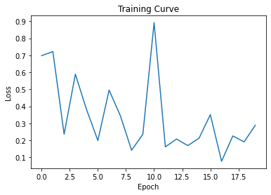

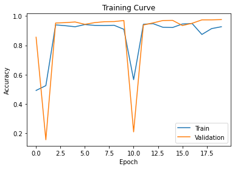

```
Testing accuracy:
```

```
0.9757630161579892
```

```python
## Hyperparameter of choice: Epochs

hidden_size = 100
num_classes = 2
model = SMSSpamLSTM2(115, hidden_size, num_classes)

train_rnn_network(model, train, valid, num_epochs=20, batch_size=64, learning_rate=2e-4)
print('Testing accuracy: ')
get_accuracy(model, test, batch_size=64)
```

### Part (d) [1 pt]

Before we deploy a machine learning model, we usually want to have a better understanding of how our model performs beyond its validation accuracy. An important metric to track is *how well our model performs in certain subsets of the data*.

In particular, what is the model's error rate amongst data with negative labels? This is called the **false positive rate**.

What about the model's error rate amongst data with positive labels? This is called the **false negative rate**.

Report your final model's false positive and false negative rate across the validation set.

```python
# Create a Dataset of only spam validation examples
valid_spam = torchtext.legacy.data.Dataset(
    [e for e in valid.examples if e.label == 1],
    valid.fields)
# Create a Dataset of only non-spam validation examples
valid_nospam = torchtext.legacy.data.Dataset([e for e in valid.examplse if e.label == 0], valid.fields) # TODO
```

```python
import torch


def confusion(prediction, truth):
    """ Returns the confusion matrix for the values in the `prediction` and `truth`
    tensors, i.e. the amount of positions where the values of `prediction`
    and `truth` are
    - 1 and 1 (True Positive)
    - 1 and 0 (False Positive)
    - 0 and 0 (True Negative)
    - 0 and 1 (False Negative)
    """

    # print(prediction.dtype)
    # print(truth)
    confusion_vector = prediction / truth
    # Element-wise division of the 2 tensors returns a new tensor which holds a
    # unique value for each case:
    #   1     where prediction and truth are 1 (True Positive)
    #   inf   where prediction is 1 and truth is 0 (False Positive)
    #   nan   where prediction and truth are 0 (True Negative)
    #   0     where prediction is 0 and truth is 1 (False Negative)

    true_positives = torch.sum(confusion_vector == 1).item()
    false_positives = torch.sum(confusion_vector == float('inf')).item()
    true_negatives = torch.sum(torch.isnan(confusion_vector)).item()
    false_negatives = torch.sum(confusion_vector == 0).item()

    return true_positives, false_positives, true_negatives, false_negatives
```

```python
def get_false(model, data, batch_size):
    """ Compute the accuracy of the `model` across a dataset `data`

    Example usage:

    >>> model = MyRNN() # to be defined
    >>> get_accuracy(model, valid) # the variable `valid` is from above
    """
    TP, FP, TN, FN = 0, 0, 0, 0

    data_iter = torchtext.legacy.data.BucketIterator(data, batch_size=batch_size, sort_key=lambda x: len(x.sms), sort_within_batch=True,repeat=False)
    for batch in data_iter:
      sms = (batch.sms[0])
      labels = (batch.label)
      input_size = 115
      out = model(sms)
      # print(out)
      pred = out.max(1, keepdim=True)[1]
      TruePos, FalsePos, TrueNeg, FalseNeg = confusion(pred, labels)
      FN += FalseNeg
      FP += FalsePos
    return print('False positives & false negatives, respectively: ', FP, FN)
```

```python
get_false(model, valid_spam, batch_size=64)
```

```
False positives & false negatives, respectively:  0 1058
```

```python
get_false(model, valid_nospam, batch_size=64)
```

```
False positives & false negatives, respectively:  0 0
```

### Part (e) [1 pt]

The impact of a false positive vs a false negative can be drastically different. If our spam detection algorithm was deployed on your phone, what is the impact of a false positive on the phone's user? What is the impact of a false negative?

## Part 4. Evaluation [7 pt]

### Part (a) [1 pt]

Report the final test accuracy of your model.

```python
print('Testing accuracy: ')
get_accuracy(model, test, batch_size=64)
```

```
Testing accuracy:
```

```
0.9757630161579892
```

### Part (b) [1 pt]

Report the false positive rate and false negative rate of your model across the test set.

```python
get_false(model, test, batch_size=64)
```

```
False positives & false negatives, respectively:  4843 5419
```

### Part (c) [3 pt]

What is your model's prediction of the **probability** that the SMS message "machine learning is sooo cool!" is spam?

Hint: To begin, use `text_field.vocab.stoi` to look up the index of each character in the vocabulary.

```python
msg = "machine learning is sooo cool!"
import tensorflow as tf

msg_enc = torch.tensor([0, 18, 16, 17, 13, 9, 7, 3, 2, 11, 3, 6, 8, 7, 9, 7, 2, 9, 10, 2, 10, 4, 4, 4, 2, 17, 4, 4, 11, 45])
# print(msg_enc.shape)
msg_enc = torch.unsqueeze(msg_enc, dim=0)
# print(msg_enc.shape)
out_msg = model(msg_enc)
pred_msg = out_msg.max(1, keepdim=True)[1]
print(out_msg)
print(pred_msg)
```

```
tensor([[ 0.6319, -0.4727]], grad_fn=<AddmmBackward0>)
tensor([[0]])
```

### Part (d) [2 pt]

Do you think detecting spam is an easy or difficult task?

Since machine learning models are expensive to train and deploy, it is very important to compare our models against baseline models: a simple model that is easy to build and inexpensive to run that we can compare our recurrent neural network model against.

Explain how you might build a simple baseline model. This baseline model can be a simple neural network (with very few weights), a hand-written algorithm, or any other strategy that is easy to build and test.

**Do not actually build a baseline model. Instead, provide instructions on how to build it.**

I think detecting spam is a relatively easy task - it is something humans are usually (if up to date on certain cues) good at doing. Building a baseline model can begin with building a simple MLP model or even a boolean algorithm. For example, you can build a boolean chart with questions like 'does the text message reference any major companies? Are there any suspicious links in the sms?' etc to help a human classify as spam or non-spam and compare our model against it

# PART B - Transfer Learning [20 pt]

In this part we will compare our earlier model with one that takes advantage of a generative RNN model to improve the prediction. There are several ways to implement transfer learning with RNNs, here we will use an approach known as ULMFiT developed by fastai. Rather than rebuilding the model from scratch, we will take advantage of the fastai library.

Provided below is some helper code to get you started.

#### Helper Code

```python
# install relevant libraries
!pip install fastai
```

```python
# load relevant libraries
from fastai import *
import pandas as pd
import numpy as np
from functools import partial
import io
import os
from fastai.text import *
```

```python
# download SPAM data
!wget https://archive.ics.uci.edu/ml/machine-learning-databases/00228/smsspamcollection.zip
!unzip smsspamcollection.zip
```

```
--2022-03-22 19:04:51--  https://archive.ics.uci.edu/ml/machine-learning-databases/00228/smsspamcollection.zip
Resolving archive.ics.uci.edu (archive.ics.uci.edu)... 128.195.10.252
Connecting to archive.ics.uci.edu (archive.ics.uci.edu)|128.195.10.252|:443... connected.
HTTP request sent, awaiting response... 200 OK
Length: 203415 (199K) [application/x-httpd-php]
Saving to: ‘smsspamcollection.zip’

smsspamcollection.z 100%[===================>] 198.65K   969KB/s    in 0.2s

2022-03-22 19:04:51 (969 KB/s) - ‘smsspamcollection.zip’ saved [203415/203415]

Archive:  smsspamcollection.zip
  inflating: SMSSpamCollection
  inflating: readme
```

This time we will load the data using pandas.

```python
# set up data and verify
df1 = pd.read_csv('SMSSpamCollection', sep='\t',  header=None, names=['target', 'text'])
df1.head()
```

|  | target | text |
| --- | --- | --- |
| 0 | ham | Go until jurong point, crazy.. Available only ... |
| 1 | ham | Ok lar... Joking wif u oni... |
| 2 | spam | Free entry in 2 a wkly comp to win FA Cup fina... |
| 3 | ham | U dun say so early hor... U c already then say... |
| 4 | ham | Nah I don't think he goes to usf, he lives aro... |

```python
# check distribution
df1['target'].value_counts()
```

```
ham     4825
spam     747
Name: target, dtype: int64
```

Split the data into training and validation datasets.

```python
# split the data and check dimensions

from sklearn.model_selection import train_test_split

# split data into training and validation set
df_trn, df_val = train_test_split(df1, stratify = df1['target'], test_size = 0.3, random_state = 999)
```

```python
df_trn.shape, df_val.shape
```

```
((3900, 2), (1672, 2))
```

### Create the language model

Esentially, the language model contains the structure of the language (English in this case), allowing us to quickly use in a classification model, skipping the part of learning the semantics of the language from scratch.

Creating a language model from scratch can be intensive due to the sheer size of data. Instead we will download the pre-trained model, which is a neural network (NN) with an AWD_LSTM architecture. By setting pretrained = True we say to fastai to download the weights from the trained model (a corpus of 103 MM of wikipedia articles).

```python
# create pretrained language model data
data_lm = TextLMDataBunch.from_df(train_df = df_trn, valid_df = df_val, path = "")
lang_mod = language_model_learner(data_lm,  arch = AWD_LSTM, pretrained = True, drop_mult=1.)
```

```
Downloading https://s3.amazonaws.com/fast-ai-modelzoo/wt103-fwd.tgz
```

### Testing the language model

```python
for i in range(5):
  print(lang_mod.predict("The problem usually starts when", n_words=10))
```

```
The problem usually starts when it is on the American Left Hand
The problem usually starts when the main all - female changes are not to the
The problem usually starts when the first person on the Sunday Evening
The problem usually starts when a key stamps LAYS , a software or one
The problem usually starts when the British Foreign Office calls Queen
```

Each time we excecute the `predict`, we get a different random sentence, completed with the number of choosen words (`n_words`).

Try your own sentences!

```python
for i in range(5):
  print(lang_mod.predict("I hate when I wake up in", n_words=10))
```

```
I hate when I wake up in the middle of a night school thing whatever it 's
I hate when I wake up in the 5th Light , i just like Duchess
I hate when I wake up in sleep your life is ? We start considering a
I hate when I wake up in love with my ass . I ' m very
I hate when I wake up in New Canada . i am glad it
```

### Fine-tuning the language model

The language model that we have "loaded" is great for generating wikipedia-like sentances, but here we're more interested in generating data like our email dataset.

Make sure to enable GPU for this step or it make takes several hours to train.

```python
# fine-tune language model data
lang_mod.fit_one_cycle(4, max_lr= 5e-02)
lang_mod.freeze_to(-1)
lang_mod.fit_one_cycle(3, slice(1e-2/(2.6**4), 1e-2))
lang_mod.freeze_to(-2)
lang_mod.fit_one_cycle(3, slice(3e-3/(2.6**4), 1e-3))
lang_mod.unfreeze()
lang_mod.fit_one_cycle(3, slice(3e-3/(2.6**4), 1e-3))

# save language model
lang_mod.save_encoder('my_awsome_encoder')
```

| epoch | train_loss | valid_loss | accuracy | time |
| --- | --- | --- | --- | --- |
| 0 | 5.580251 | 3.844076 | 0.285714 | 00:01 |
| 1 | 4.845066 | 3.785028 | 0.285714 | 00:01 |
| 2 | 4.388670 | 3.697684 | 0.285714 | 00:01 |
| 3 | 4.067311 | 3.710549 | 0.300000 | 00:01 |

| epoch | train_loss | valid_loss | accuracy | time |
| --- | --- | --- | --- | --- |
| 0 | 3.577928 | 3.708095 | 0.328571 | 00:01 |
| 1 | 3.544739 | 3.664120 | 0.328571 | 00:01 |
| 2 | 3.484049 | 3.696889 | 0.328571 | 00:01 |

| epoch | train_loss | valid_loss | accuracy | time |
| --- | --- | --- | --- | --- |
| 0 | 3.407416 | 3.698210 | 0.314286 | 00:01 |
| 1 | 3.389957 | 3.695534 | 0.342857 | 00:01 |
| 2 | 3.366736 | 3.688240 | 0.328571 | 00:01 |

| epoch | train_loss | valid_loss | accuracy | time |
| --- | --- | --- | --- | --- |
| 0 | 3.322273 | 3.693310 | 0.328571 | 00:02 |
| 1 | 3.292140 | 3.682620 | 0.300000 | 00:02 |
| 2 | 3.258275 | 3.688397 | 0.300000 | 00:02 |

### Classification model

Now we can train a classification model that will identify spam and non-spam messages. Since we used a fastai language model, it will be easier to just continue working with the fastai library.

```python
# Classifier model data
data_clas = TextClasDataBunch.from_df(path = "", train_df = df_trn,  valid_df = df_val, vocab=data_lm.train_ds.vocab, bs=32)
```

```python
data_clas.show_batch()
```

| text | target |
| --- | --- |
| xxbos xxmaj the last thing i ever wanted to do was hurt you . xxmaj and i did n't think it would have . xxmaj you 'd laugh , be embarassed , delete the xxunk and keep going . xxmaj but as far as i kne… | ham |
| xxbos xxmaj sad story of a xxmaj man - xxmaj last week was my b'day . xxmaj my xxmaj wife did'nt wish me . xxmaj my xxmaj parents forgot n so did my xxmaj kids . i went to work . xxmaj even my xxmaj c… | ham |
| xxbos xxmaj for me the love should start with xxunk should feel that i need her every time around xxunk should be the first thing which comes in my thoughts . i would start the day and end it with xxu… | ham |
| xxbos xxmaj indians r poor but xxmaj india is not a poor country . xxmaj says one of the swiss bank xxunk . xxmaj he says that " < # > xxunk crore " of xxmaj indian money is xxunk in swiss banks which… | ham |
| xxbos xxmaj good evening xxmaj sir , hope you are having a nice day . i wanted to bring it to your notice that i have been late in paying rent for the past few months and have had to pay a $ < # > cha… | ham |

```python
# create the classifier
learn_classifier = text_classifier_learner(data_clas, drop_mult=0.7, arch = AWD_LSTM)
```

```python
# load language model
learn_classifier.load_encoder('my_awsome_encoder')
```

[output not shown]

[output cut: 34 more lines]

[output not shown]

0.00% [0/1 00:00<00:00]

| epoch | train_loss | valid_loss | accuracy | time |
| --- | --- | --- | --- | --- |

71.90% [87/121 00:01<00:00 0.5312]

```
LR Finder is complete, type {learner_name}.recorder.plot() to see the graph.
Min numerical gradient: 1.74E-01
Min loss divided by 10: 5.25E-02
```

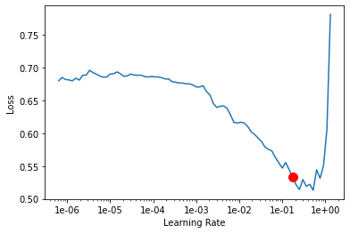

```python
# train classifier
learn_classifier.lr_find()
learn_classifier.recorder.plot(suggestion=True)
```

```python
learn_classifier.fit_one_cycle(5, max_lr=1e-2, moms=(0.8,0.7))
```

| epoch | train_loss | valid_loss | accuracy | time |
| --- | --- | --- | --- | --- |
| 0 | 0.383878 | 0.080374 | 0.976077 | 00:03 |
| 1 | 0.176713 | 0.061538 | 0.986842 | 00:03 |
| 2 | 0.111191 | 0.071442 | 0.985048 | 00:03 |
| 3 | 0.080739 | 0.084641 | 0.975478 | 00:02 |
| 4 | 0.079224 | 0.082174 | 0.983254 | 00:03 |

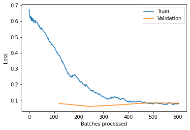

```python
learn_classifier.recorder.plot_losses()
```

0.00% [0/1 00:00<00:00]

| epoch | train_loss | valid_loss | accuracy | time |
| --- | --- | --- | --- | --- |

62.81% [76/121 00:01<00:00 0.0842]

```
LR Finder is complete, type {learner_name}.recorder.plot() to see the graph.
Min numerical gradient: 1.10E-06
Min loss divided by 10: 5.75E-05
```

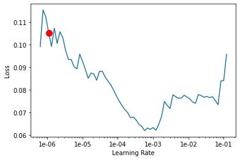

```python
lang_mod.freeze_to(-1)

learn_classifier.lr_find()
learn_classifier.recorder.plot(suggestion=True)
```

Test out the classification model on spam and non-spam examples.

```python
# predict
learn_classifier.predict('did you buy the groceries for dinner? :)')
```

```
(Category tensor(0), tensor(0), tensor([1.0000e+00, 4.6387e-07]))
```

```python
# predict
learn_classifier.predict('Free entry call back now')
```

```
(Category tensor(1), tensor(1), tensor([0.1735, 0.8265]))
```

Next we will evaluate on all of our validation data.

```python
# get predictions from validation
valid_preds, valid_label=learn_classifier.get_preds(ds_type=DatasetType.Valid, ordered=True)
valid_preds.shape
```

```
torch.Size([1672, 2])
```

```python
display(valid_label.shape)
```

```
torch.Size([1672])
```

## Part 1. Evaluate Performance [10pt]

### Part (a) [5pt]

Implement the above helper code for spam detection.

What is the accuracy obtained with ULMFiT? How does ULMFiT compare to the approach in the first part using only LSTM?

```python
# valid_preds, valid_label=learn_classifier.get_preds(ds_type=DatasetType.Valid, ordered=True)
# train_preds, train_label=learn_classifier.get_preds(ds_type=DatasetType.Train, ordered=True)
# test_preds, test_label=learn_classifier.get_preds(ds_type=DatasetType.Test, ordered=True)

# test_preds, test_label = learn_classifier.get_preds(ds_type=DatasetType.Test, ordered=True)

display(valid_label[:10], valid_preds[:10])
```

```
tensor([0, 1, 0, 0, 0, 0, 0, 0, 0, 0])
```

```
tensor([[1.0000e+00, 4.5036e-10],
        [6.2933e-02, 9.3707e-01],
        [9.9998e-01, 2.0345e-05],
        [1.0000e+00, 5.9442e-17],
        [1.0000e+00, 8.4037e-07],
        [1.0000e+00, 5.3602e-15],
        [1.0000e+00, 2.3170e-08],
        [1.0000e+00, 2.8205e-09],
        [1.0000e+00, 2.0342e-12],
        [1.0000e+00, 3.5495e-06]])
```

```python
df_val.iloc[:,0]
label_vector = []

for i in range(len(df_val)):
  label = df_val.iloc[i,0]
  if label=='ham':
    label_vector.append(0)
  elif label=='spam':
    label_vector.append(1)

# display(label_vector)
label_vector = torch.tensor(label_vector)
display(label_vector)

true_label = label_vector.numpy()
# pred_label = valid_label.numpy()
pred_label_prob = valid_preds.numpy()

num_acc = []
pred_label = []

for i in range(len(true_label)):
  true = true_label[i]
  pred_prob = pred_label_prob[i, :]
  if pred_prob[0]>pred_prob[1]:
    pred = 0
    pred_label.append(pred)
  else:
    pred = 1
    pred_label.append(pred)
  if true==pred:
    num_acc.append(1)

total_correct = len(num_acc)
total = len(true_label)

final_val_acc = total_correct/total

print('Final validation accuracy: ', final_val_acc)
```

```
tensor([0, 1, 0,  ..., 1, 0, 1])
```

```
Final validation accuracy:  0.9832535885167464
```

### Part (b) [5pt]

Provide a confusion matrix of the performance for the two models. How do they compare? Are there any qualitative differences between the performances (i.e. examine the samples for which the models differred)?

The ULMFit model has MUCH better performance in terms of FP and FN compared to the LSTM model I built. If I were to deploy one, I would definitely pick the ULMFiT model even though their accuracies are very similar.

```python
def get_false_full(model, data, batch_size):
    """ Compute the accuracy of the `model` across a dataset `data`

    Example usage:

    >>> model = MyRNN() # to be defined
    >>> get_accuracy(model, valid) # the variable `valid` is from above
    """
    TP, FP, TN, FN = 0, 0, 0, 0

    data_iter = torchtext.legacy.data.BucketIterator(data, batch_size=batch_size, sort_key=lambda x: len(x.sms), sort_within_batch=True,repeat=False)
    for batch in data_iter:
      sms = (batch.sms[0])
      labels = (batch.label)
      input_size = 115
      out = model(sms)
      # print(out)
      pred = out.max(1, keepdim=True)[1]
      TruePos, FalsePos, TrueNeg, FalseNeg = confusion(pred, labels)
      FN = FalseNeg
      FP = FalsePos
      TP = TruePos
      TN = TrueNeg
    return  [[TN, FP], [FN, TP]]
```

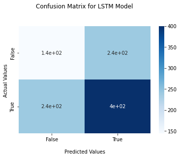

```python
from sklearn.metrics import confusion_matrix
import seaborn as sns

cf_matrix_LSTM=get_false_full(model, valid, 32)
ax = sns.heatmap(cf_matrix_LSTM, annot=True, cmap='Blues')

ax.set_title('Confusion Matrix for LSTM Model\n\n');
ax.set_xlabel('\nPredicted Values')
ax.set_ylabel('Actual Values ');

## Ticket labels - List must be in alphabetical order
ax.xaxis.set_ticklabels(['False','True'])
ax.yaxis.set_ticklabels(['False','True'])

## Display the visualization of the Confusion Matrix.
plt.show()
```

[output not shown]

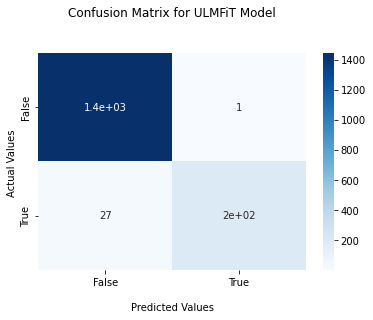

```python
from sklearn.metrics import confusion_matrix
import seaborn as sns



cf_matrix_ULMFiT = confusion_matrix(y_true=true_label, y_pred=pred_label)
# display(cf_matrix_ULMFiT)
ax = sns.heatmap(cf_matrix_ULMFiT, annot=True, cmap='Blues')

ax.set_title('Confusion Matrix for ULMFiT Model\n\n');
ax.set_xlabel('\nPredicted Values')
ax.set_ylabel('Actual Values ');

## Ticket labels - List must be in alphabetical order
ax.xaxis.set_ticklabels(['False','True'])
ax.yaxis.set_ticklabels(['False','True'])

## Display the visualization of the Confusion Matrix.
plt.show()
```

## Part 2. Evaluate on New Data [10pt]

### Part (a) [4pt]

What is your model's prediction of the probability that the SMS message "machine learning is sooo cool!" is spam?

```python
learn_classifier.predict('machine learning is sooo cool!')
```

```
(Category tensor(0), tensor(0), tensor([1.0000e+00, 6.7906e-28]))
```

The model predicts that the message is not spam

### Part (b) [3 pt]

Load 5 sample sentences from your spam mail and test it out out the two models you created. How well do they perform?

```python
learn_classifier.predict('this weekly grant of $200.00 has arrived and youre eligible to claim it. More details below. https://bit.ly/ENTITLEMENTRETURN')
```

```
(Category tensor(1), tensor(1), tensor([0.0723, 0.9277]))
```

SPAM ^

```python
learn_classifier.predict('AmazOn: Our Security Team will put your embership on hold, please see: qak.me/z5')
```

```
(Category tensor(0), tensor(0), tensor([0.5716, 0.4284]))
```

NOT SPAM ^

```python
learn_classifier.predict('SUPP-N3TFLIX.INF0S(C0DE#SL2329) We failed to bill your card. Update here: https://64.227.17.148')
```

```
(Category tensor(1), tensor(1), tensor([0.2779, 0.7221]))
```

^ SPAM

```python
learn_classifier.predict('INTERAC e-transfer: Your monthly phone bill was overcharged by 120.23$ Click here to Deposity your funds: https://receivetransferpay.shop/')
```

```
(Category tensor(1), tensor(1), tensor([0.3260, 0.6740]))
```

^ SPAM

```python
learn_classifier.predict('Netflix: Your pyment has failed. You can update your info here: bit.ly/34YdR5m If we were unable to charge your payment method, we will cancel the service. Send STOP to opt-out')
```

```
(Category tensor(1), tensor(1), tensor([0.3532, 0.6468]))
```

^ SPAM

```python
print('The classification accuracy on the 5 loaded spam messages was: ', 4/5)
```

```
The classification accuracy on the 5 loaded spam messages was:  0.8
```

### Part (c) [3pt]

Load 5 sample sentences from your regular mail and test it out out the two models you created. How well do they perform?

```python
learn_classifier.predict('Switch Health: Your Day 8 test is coming up! If you have been exempt from this testing requirement, please disregard this message.')
```

```
(Category tensor(0), tensor(0), tensor([0.8695, 0.1305]))
```

^ Not spam

```python
learn_classifier.predict('Get ready! Table for 2 at La Vecchia - Marine Parade on 05-02-22 Sat 20:00.')
```

```
(Category tensor(1), tensor(1), tensor([0.3299, 0.6701]))
```

^ Spam

```python
learn_classifier.predict('Your DHL Express shipment 5651907634 from CULT BEAUTY was delivered Fri Feb 04 at 15:29. Tell us how we did.')
```

```
(Category tensor(0), tensor(0), tensor([0.9186, 0.0814]))
```

^ Not spam

```python
learn_classifier.predict('Hahaha probably be the only black person in town but thats not a first')
```

```
(Category tensor(0), tensor(0), tensor([9.9999e-01, 8.4682e-06]))
```

^ Not spam

```python
learn_classifier.predict('I hate them so annoying')
```

```
(Category tensor(0), tensor(0), tensor([1.0000e+00, 3.1333e-30]))
```

^ Not spam

```python
print('The classification accuracy on the 5 loaded non-spam messages was: ', 4/5)
```

```
The classification accuracy on the 5 loaded non-spam messages was:  0.8
```

### Saving to HTML

Detailed instructions for saving to HTML can be found [here](https://stackoverflow.com/questions/53460051/convert-ipynb-notebook-to-html-in-google-colab/64487858#64487858). Provided below are a summary of the instructions:

(1) download your ipynb file by clicking on File->Download.ipynb

(2) reupload your file to the temporary Google Colab storage (you can access the temporary storage from the tab to the left)

(3) run the following:

```python
%%shell
jupyter nbconvert --to html LAB_4_Sequential_Data.ipynb
```

[output not shown]

(4) the html file will be available for download in the temporary Google Colab storage

(5) review the html file and make sure all the results are visible before submitting your assignment to Quercus